# Solusi Sistem Persamaan Nonlinear (SPNL)

Metode Numerik (MTK0315)

Dr. Indira Puteri Kinasih

indiraputeri@uinmataram.ac.id

Universitas Islam Negeri Mataram

## Tujuan Pembelajaran

Setelah mengikuti materi ini, mahasiswa mampu:

- menjelaskan konsep SPNL;
- menuliskan SPNL dalam bentuk vektor;
- menentukan matriks Jacobian;
- menjelaskan ide metode Newton untuk SPNL;
- melakukan iterasi Newton;
- mengimplementasikan metode Newton menggunakan R;
- mengevaluasi konvergensi solusi.

## Pernahkah kita tahu luas benda, tetapi tidak tahu ukurannya?

Bayangkan sebuah **karpet berbentuk persegi panjang**.

Kita tidak mengetahui panjang dan lebarnya.

Yang diketahui:

- luas karpet = **48 m²**
- diagonal karpet = **10 m**

Kita ingin mengetahui:

$$\text{panjang}=x
\qquad
\text{lebar}=y$$

## Dari informasi ke persamaan

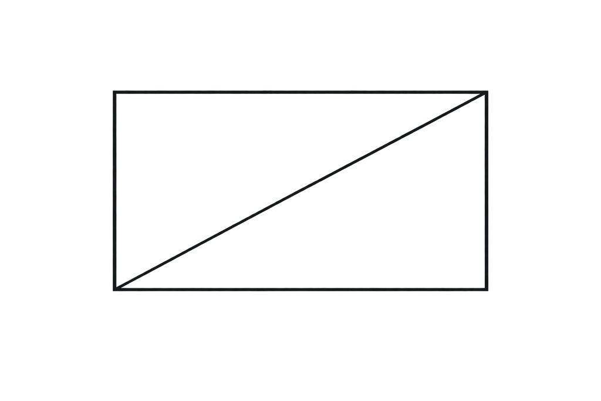

Dari luas:

$$xy=48$$

Dari Teorema Pythagoras:

$$x^2+y^2=10^2$$

Sehingga:

$$\boxed{
\begin{cases}
xy-48=0\\
x^2+y^2-100=0
\end{cases}}$$

## Apa yang sebenarnya kita cari?

Kita mencari **satu pasangan $(x,y)$** yang memenuhi:

$$xy-48=0$$

dan

$$x^2+y^2-100=0$$

**secara bersamaan.**

Coba tebak.

$$x=6,\qquad y=8$$

Apakah memenuhi kedua persamaan?

$$6(8)=48$$

dan

$$6^2+8^2=100.$$

Ya.

## Tetapi bagaimana jika…

Bagaimana jika persamaannya tidak sesederhana ini?

Misalnya:

$$\begin{cases}
f_1(x,y)=0\\
f_2(x,y)=0
\end{cases}$$

dan solusi **tidak dapat ditebak atau diperoleh dengan mudah secara aljabar**.

Kita membutuhkan:

$$\boxed{\text{metode numerik}}$$

Salah satu metode yang akan kita pelajari:

$$\boxed{\text{Newton untuk SPNL}}$$

## Dari masalah nyata → model → metode numerik

**Masalah nyata**

> Berapa panjang dan lebar karpet?

↓

**Model matematika**

$$\begin{cases}
xy-48=0\\
x^2+y^2-100=0
\end{cases}$$

↓

**Bentuk umum**

$$\mathbf F(\mathbf x)=\mathbf 0$$

↓

**Metode numerik**

$$\boxed{\text{Newton}}$$

# Mengapa SPNL?

## Dari satu persamaan…

Sebelumnya kita menyelesaikan:

$$f(x)=0$$

Misalnya:

$$x^2-4=0$$

Solusinya:

$$x=-2,\quad x=2$$

Metode numerik membantu ketika solusi analitik sulit diperoleh.

## …menjadi beberapa persamaan

Sekarang kita memiliki:

$$\begin{cases}
x^2+y^2-4=0,\\
x^2-y-1=0.
\end{cases}$$

Kita mencari **$x$ dan $y$ secara simultan**.

Jadi, yang dicari bukan lagi satu angka:

$$x$$

tetapi sebuah vektor:

$$\mathbf{x}
=
\begin{bmatrix}
x\\y
\end{bmatrix}.$$

## Secara geometris

Setiap persamaan membentuk sebuah kurva.

Solusi SPNL adalah:

> **titik perpotongan kurva-kurva tersebut.**

$$\begin{cases}
x^2+y^2=4,\\
y=x^2-1.
\end{cases}$$

## Contoh visual

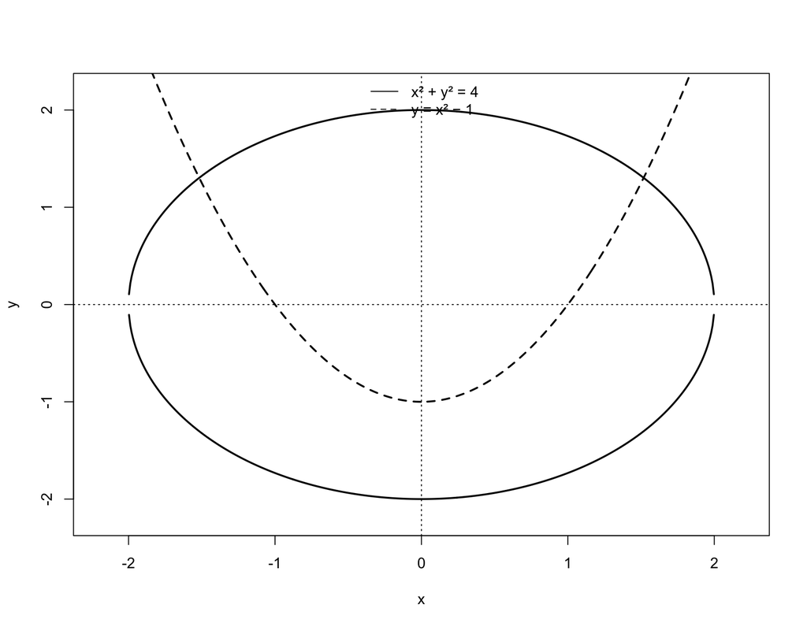

# Bentuk Vektor

## SPNL

Secara umum:

$$\begin{aligned}
f_1(x_1,\ldots,x_n)&=0\\
f_2(x_1,\ldots,x_n)&=0\\
&\vdots\\
f_n(x_1,\ldots,x_n)&=0
\end{aligned}$$

dapat ditulis:

$$\boxed{\mathbf{F}(\mathbf{x})=\mathbf{0}}$$

## Contoh

Untuk

$$\begin{cases}
x^2+y^2-4=0,\\
x^2-y-1=0,
\end{cases}$$

definisikan:

$$\mathbf{F}(x,y)
=
\begin{bmatrix}
x^2+y^2-4\\
x^2-y-1
\end{bmatrix}.$$

Sehingga:

$$\boxed{
\mathbf{F}(x,y)=
\begin{bmatrix}
0\\0
\end{bmatrix}
}$$

# Dari Newton-Raphson ke SPNL

## Newton satu variabel

Untuk

$$f(x)=0,$$

Newton-Raphson:

$$\boxed{
x_{k+1}
=
x_k-\frac{f(x_k)}{f'(x_k)}
}$$

Pertanyaannya:

> Apa yang berubah ketika (x) menjadi vektor?

## Satu variabel vs banyak variabel

| Satu variabel | SPNL |
| --- | --- |
| $x$ | $\mathbf{x}$ |
| $f(x)$ | $\mathbf{F}(\mathbf{x})$ |
| $f'(x)$ | $J(\mathbf{x})$ |
| pembagian | sistem linear |
| $x_{k+1}$ | $\mathbf{x}_{k+1}$ |

Ide dasarnya **tetap sama**:

$$\text{estimasi lokal}
\rightarrow
\text{koreksi}
\rightarrow
\text{update}$$

# Jacobian

## Apa itu Jacobian?

Jacobian adalah kumpulan seluruh turunan parsial:

$$J(\mathbf{x})
=
\begin{bmatrix}
\frac{\partial f_1}{\partial x_1}
&
\cdots
&
\frac{\partial f_1}{\partial x_n}
\\
\vdots
&
\ddots
&
\vdots
\\
\frac{\partial f_n}{\partial x_1}
&
\cdots
&
\frac{\partial f_n}{\partial x_n}
\end{bmatrix}.$$

Sederhananya:

> **Jacobian = versi multivariat dari turunan pertama.**

## Contoh Jacobian

Diberikan:

$$f_1(x,y)=x^2+y^2-4$$

$$f_2(x,y)=x^2-y-1$$

Turunan parsial:

$$\frac{\partial f_1}{\partial x}=2x,
\qquad
\frac{\partial f_1}{\partial y}=2y$$

$$\frac{\partial f_2}{\partial x}=2x,
\qquad
\frac{\partial f_2}{\partial y}=-1$$

## Maka Jacobian-nya

$$\boxed{
J(x,y)
=
\begin{bmatrix}
2x&2y\\
2x&-1
\end{bmatrix}
}$$

Perhatikan:

$$\boxed{
\text{turunan}
\quad\longrightarrow\quad
\text{turunan parsial}
\quad\longrightarrow\quad
\text{Jacobian}
}$$

# Ide Newton untuk SPNL

## Aproksimasi linear

$$\mathbf{F}(\mathbf{x}_k+\Delta\mathbf{x})
\approx
\mathbf{F}(\mathbf{x}_k)
+
J(\mathbf{x}_k)\Delta\mathbf{x}.$$

Kita ingin:

$$\mathbf{F}(\mathbf{x}_{k+1})\approx\mathbf{0}.$$

Maka:

$$\mathbf{F}(\mathbf{x}_k)
+
J(\mathbf{x}_k)\Delta\mathbf{x}
\approx
\mathbf{0}.$$

## Persamaan utama

Susun ulang:

$$J(\mathbf{x}_k)\Delta\mathbf{x}
=
-\mathbf{F}(\mathbf{x}_k).$$

Setelah $\Delta\mathbf{x}$ diperoleh:

$$\boxed{
\mathbf{x}_{k+1}
=
\mathbf{x}_k+\Delta\mathbf{x}
}$$

Inilah **Newton untuk SPNL**.

# Contoh Iterasi

## Sistem

$$\begin{cases}
x^2+y^2-4=0,\\
x^2-y-1=0.
\end{cases}$$

Tebakan awal:

$$\mathbf{x}_0=
\begin{bmatrix}
1\\1
\end{bmatrix}$$

## Evaluasi fungsi

$$\mathbf{F}(1,1)
=
\begin{bmatrix}
-2\\
-1
\end{bmatrix}$$

dan

$$J(1,1)
=
\begin{bmatrix}
2&2\\
2&-1
\end{bmatrix}.$$

## Cari koreksi

Kita selesaikan:

$$\begin{bmatrix}
2&2\\
2&-1
\end{bmatrix}
\begin{bmatrix}
\Delta x\\
\Delta y
\end{bmatrix}
=
\begin{bmatrix}
2\\
1
\end{bmatrix}.$$

## Update

Kemudian proses diulang.

# Algoritma

## Newton SPNL

```
Pilih x₀

Untuk k = 0, 1, 2, ...

    Hitung F(xₖ)

    Hitung J(xₖ)

    Selesaikan:
        J(xₖ) Δx = −F(xₖ)

    Update:
        xₖ₊₁ = xₖ + Δx

    Periksa konvergensi

Berhenti jika memenuhi toleransi
```

## Hal yang perlu diingat

Pada setiap iterasi:

$$\boxed{
\text{1. Hitung fungsi}
}$$

$$\boxed{
\text{2. Hitung Jacobian}
}$$

$$\boxed{
\text{3. Cari koreksi}
}$$

$$\boxed{
\text{4. Update solusi}
}$$

$$\boxed{
\text{5. Cek konvergensi}
}$$

# Implementasi R

## Definisikan fungsi

```r
F <- function(x) {
  c(
    x[1]^2 + x[2]^2 - 4,
    x[1]^2 - x[2] - 1
  )
}
```

## Definisikan Jacobian

```r
J <- function(x) {
  matrix(
    c(
      2*x[1], 2*x[2],
      2*x[1], -1
    ),
    nrow = 2,
    byrow = TRUE
  )
}
```

## Cek pada tebakan awal

```r
x <- c(1, 1)

F(x)
```

```
[1] -2 -1
```

```r
J(x)
```

```
     [,1] [,2]
[1,]    2    2
[2,]    2   -1
```

# Langkah Inti di R

## Menyelesaikan sistem linear

Kita membutuhkan:

$$J(x)\Delta x=-F(x)$$

Dalam R:

```r
delta <- solve(
  J(x),
  -F(x)
)

delta
```

```
[1] 0.6666667 0.3333333
```

Kemudian:

```r
x_new <- x + delta

x_new
```

```
[1] 1.666667 1.333333
```

Jadi inti Newton SPNL hanya membutuhkan:

```r
delta <- solve(J(x), -F(x))
x_new <- x + delta
```

# Fungsi Newton

## Implementasi

```r
newton_spnl <- function(F, J, x0,
                        tol = 1e-8,
                        max_iter = 100) {

  x <- x0

  for (k in 1:max_iter) {

    Fx <- F(x)
    Jx <- J(x)

    delta <- solve(Jx, -Fx)

    x_new <- x + delta

    if (sqrt(sum(F(x_new)^2)) < tol) {

      return(list(
        solution = x_new,
        iterations = k,
        converged = TRUE
      ))

    }

    x <- x_new
  }

  list(
    solution = x,
    iterations = max_iter,
    converged = FALSE
  )
}
```

# Menjalankan Metode

## Tebakan awal

```r
hasil <- newton_spnl(
  F = F,
  J = J,
  x0 = c(1, 1)
)
```

Solusi:

```r
hasil$solution
```

```
[1] 1.517490 1.302776
```

Jumlah iterasi:

```r
hasil$iterations
```

```
[1] 4
```

Konvergensi:

```r
hasil$converged
```

```
[1] TRUE
```

# Memeriksa Solusi

## Jangan hanya melihat hasil $x$ dan $y$

Solusi harus dimasukkan kembali ke sistem.

```
[1] 2.238885e-10 2.238880e-10
```

Idealnya:

$$\mathbf{F}(\mathbf{x}^*)
\approx
\begin{bmatrix}
0\\0
\end{bmatrix}.$$

## Residual

Gunakan norm:

$$\boxed{
\|\mathbf{F}(\mathbf{x}^*)\|
}$$

Dalam R:

```r
sqrt(sum(
  F(hasil$solution)^2
))
```

```
[1] 3.166258e-10
```

Semakin dekat ke nol, semakin baik solusi numeriknya.

## Kriteria Konvergensi

### Berdasarkan residual

$$\boxed{
\|\mathbf{F}(\mathbf{x}_k)\|<\varepsilon
}$$

Artinya fungsi sudah mendekati nol.

### Berdasarkan perubahan solusi

$$\boxed{
\|\mathbf{x}_{k+1}-\mathbf{x}_k\|<\varepsilon
}$$

Artinya perubahan antariterasi sudah sangat kecil.

## Praktik yang lebih aman

Periksa keduanya:

$$\|\mathbf{F}(\mathbf{x}_k)\|<\varepsilon$$

dan

$$\|\mathbf{x}_{k+1}-\mathbf{x}_k\|<\varepsilon.$$

Perubahan solusi yang kecil **tidak selalu berarti** residual sudah kecil.

# Mengapa Tebakan Awal Penting?

## Newton bukan metode bracketing

Pada metode bisection, kita mencari interval:

$$f(a)f(b)<0.$$

Newton tidak membutuhkan interval tersebut.

Namun:

> Newton sangat bergantung pada posisi tebakan awal.

Tebakan awal yang berbeda dapat menghasilkan:

- solusi yang berbeda;
- jumlah iterasi yang berbeda;
- atau kegagalan konvergensi.

## Eksperimen Tebakan Awal

Coba:

```
[[1]]
        x         y   iterasi konvergen
 1.517490  1.302776  4.000000  1.000000

[[2]]
        x         y   iterasi konvergen
-1.517490  1.302776  4.000000  1.000000

[[3]]
        x         y   iterasi konvergen
 1.517490  1.302776  4.000000  1.000000

[[4]]
        x         y   iterasi konvergen
-1.517490  1.302776  4.000000  1.000000
```

Pertanyaan:

> Apakah semua tebakan awal menghasilkan solusi yang sama?

## Mengapa Bisa Ada Banyak Solusi?

Perhatikan:

$$\begin{cases}
x^2+y^2=4,\\
y=x^2-1.
\end{cases}$$

Kurva dapat berpotongan di lebih dari satu titik.

Maka:

$$\boxed{
\text{Satu SPNL tidak selalu memiliki satu solusi.}
}$$

Newton dapat menuju salah satu solusi bergantung pada tebakan awal.

## Visualisasi Solusi

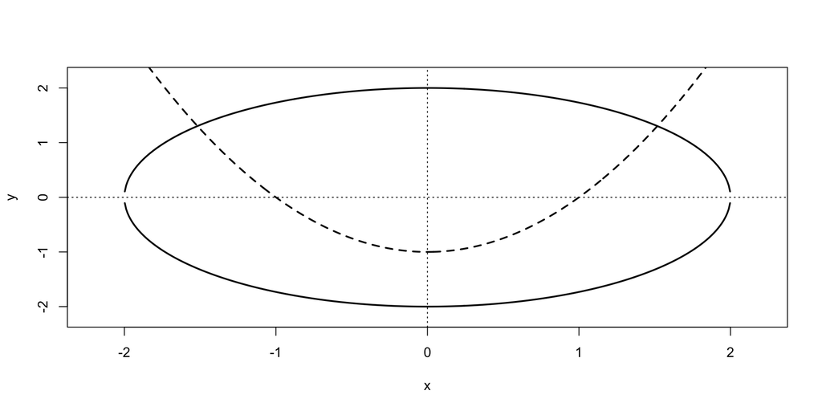

Solusi SPNL dapat dipahami sebagai:

$$\boxed{
\text{titik perpotongan kurva}
}$$

## Bagaimana Newton Bergerak?

Secara konseptual:

```
Tebakan awal
     ↓
Evaluasi F(x)
     ↓
Hitung Jacobian
     ↓
Cari arah koreksi
     ↓
Update x
     ↓
Lebih dekat ke solusi?
     ↓
   Ya → selesai
   Tidak → ulangi
```

Metode Newton secara bertahap memperbaiki posisi solusi.

## Masalah Jacobian Singular

Newton membutuhkan penyelesaian:

$$J(\mathbf{x}_k)\Delta\mathbf{x}
=
-\mathbf{F}(\mathbf{x}_k).$$

Jika Jacobian singular:

$$\det J(\mathbf{x}_k)=0,$$

sistem linear tidak memiliki solusi unik.

Dalam R:

```
[1] -6
```

Kita juga dapat melihat kondisi matriks:

```
[1] 1.416667
```

Nilai `kappa()` yang besar menunjukkan Jacobian dapat bersifat ill-conditioned.

## Newton SPNL: Inti Konsep

$$\boxed{
\mathbf{F}(\mathbf{x})=\mathbf{0}
}$$

↓

$$\boxed{
J(\mathbf{x}_k)\Delta\mathbf{x}
=
-\mathbf{F}(\mathbf{x}_k)
}$$

↓

$$\boxed{
\mathbf{x}_{k+1}
=
\mathbf{x}_k+\Delta\mathbf{x}
}$$

↓

Ulangi sampai konvergen.

## Perbandingan

|  | Newton 1D | Newton SPNL |
| --- | --- | --- |
| Fungsi | $f(x)$ | $\mathbf F(\mathbf x)$ |
| Turunan | $f'(x)$ | $J(\mathbf x)$ |
| Koreksi | skalar | vektor |
| Operasi | pembagian | sistem linear |
| Solusi | $x$ | $\mathbf x$ |
| Geometri | akar kurva | titik potong kurva |

## Latihan 1

Diberikan:

$$\begin{cases}
x^2+y^2-5=0,\\
e^x+y-1=0.
\end{cases}$$

Tentukan:

1. $\mathbf F(x,y)$
2. $J(x,y)$

## Latihan 2

Gunakan:

$$\begin{cases}
x^2+y^2-5=0,\\
x-y-1=0.
\end{cases}$$

Dengan tebakan awal:

$$(x_0,y_0)=(1,1)$$

Tentukan:

- solusi;
- jumlah iterasi;
- residual;
- status konvergensi.

Gunakan:

$$\varepsilon=10^{-8}.$$

## Latihan 3

Gunakan sistem:

$$\begin{cases}
x^2+y^2-4=0,\\
x^2-y-1=0.
\end{cases}$$

Bandingkan tebakan awal:

$$(1,1),\quad
(-1,1),\quad
(2,2),\quad
(-2,2).$$

Buat tabel:

| Tebakan | Solusi | Iterasi | Konvergen |
| --- | --- | --- | --- |
| $(1,1)$ |  |  |  |
| $(-1,1)$ |  |  |  |
| $(2,2)$ |  |  |  |
| $(-2,2)$ |  |  |  |

## Latihan 4 — Tiga Peubah

Diberikan:

$$\begin{cases}
x+y+z-3=0,\\
x^2+y^2+z^2-5=0,\\
e^x+y-z-1=0.
\end{cases}$$

Tentukan:

1. $\mathbf F(x,y,z)$;
2. $J(x,y,z)$;
3. solusi numerik;
4. residual;
5. jumlah iterasi.

Gunakan R.

## Pertanyaan Diskusi

1. Mengapa Jacobian dapat dianggap sebagai generalisasi turunan?
2. Mengapa Newton SPNL membutuhkan penyelesaian sistem linear?
3. Mengapa invers Jacobian tidak perlu dihitung secara eksplisit?
4. Mengapa tebakan awal penting?
5. Mengapa satu SPNL dapat memiliki beberapa solusi?
6. Apa yang dapat menyebabkan Newton gagal konvergen?
7. Mengapa solusi numerik perlu diperiksa dengan residual?

## Ringkasan

SPNL:

$$\boxed{\mathbf F(\mathbf x)=\mathbf 0}$$

Jacobian:

$$\boxed{J(\mathbf x)}$$

Koreksi Newton:

$$\boxed{
J(\mathbf x_k)\Delta\mathbf x
=
-\mathbf F(\mathbf x_k)
}$$

Update:

$$\boxed{
\mathbf x_{k+1}
=
\mathbf x_k+\Delta\mathbf x
}$$

Kriteria:

$$\boxed{
\|\mathbf F(\mathbf x_k)\|<\varepsilon
}$$

## Pesan Utama

Metode Newton untuk SPNL pada dasarnya adalah:

$$\boxed{
\text{Newton-Raphson}
+
\text{turunan parsial}
+
\text{sistem linear}
}$$

atau secara konseptual:

$$\boxed{
\text{tebak}
\rightarrow
\text{evaluasi}
\rightarrow
\text{koreksi}
\rightarrow
\text{update}
\rightarrow
\text{periksa}
}$$

**Kunci pemahaman:**

> Jacobian memberikan informasi lokal tentang bagaimana seluruh persamaan berubah terhadap seluruh peubah.